# Tn-Seq correction of fitness in a circular genome

Daniele Colombo

2022-07-05

# Introduction

Tn-seq is a method that can be used to evaluate the fitness of a gene (i.e. how fundamental is a gene for cell survival and reproduction) by transposon insertion. The cells studied are used to build a library under a test condition and the transposons junctions inserted in the genomes are sequenced. The change in frequency of each insertion and the population size in the test condition are used to compute the fitness, which is a quantitative measure of growth rate.

In this vignette, the data coming from Tn-seq applied to S.pneumoniae is used (Source: van Opijnen et al, 2009. https://doi-org.pros1.lib.unimi.it/10.1038/nmeth.1377) The aim of this project is to correct the bias of fitness data, which is introduced by DNA replication, that causes a higher amount of DNA present in the cell for the sequences nearest to the replication fork. This change in DNA amounts causes a higher measured fitness for genes in their proximity. These regions are at the two extremities of the linearized chromosome, which are actually contiguous as the bacterial genome is circular. This effect causes a ‘smile shape’ in the distribution of the fitness over the genome position, which leads to the wrong classification of many genes, especially the ones in the chromosome extremities and its middle region.

## Dependencies

The main packages used for this analysis are from the following packages:

```r
# if (!require("BiocManager", quietly = TRUE))
#     install.packages("BiocManager")
# BiocManager::install("GenomicRanges")

library("GenomicRanges")
library("cowplot")
library("ggplot2")
library("dplyr")
library("scales")
library('ggsankey')
```

# Data loading and preprocessing

The data is imported through a tsv file:

```r
fitness_data <- na.omit(read.table("data/Tn_seq_fitness_data_Opijnen_et_al_2009.txt",
                                   header=TRUE, stringsAsFactors = FALSE, sep ="\t"))

gene_coordinates <- read.table("data/GCF_000006885.1_ASM688v1_genomic_olt.txt",
                               header=FALSE, stringsAsFactors=FALSE, sep = "\t",
                               col.names=c('locus','start','end'))
```

The fitness_data and gene_coordinates dataframes are then merged in a single dataframe using the gene id and converted in a GRanges object (defined in the GenomicRanges package from Bioconductor) which allows for an easier management of genomic ranges:

```r
# Merge data
merged_fitness <- merge(fitness_data, gene_coordinates, by='locus')

# Convert data into genomic ranges
fitness_gr <- GRanges(seqnames = Rle("chr", nrow(merged_fitness)),
                      ranges = IRanges(start=merged_fitness$start,
                                       end=merged_fitness$end,
                                       names=merged_fitness$locus),
                      avg_fitness = merged_fitness$average_fitness)
```

The GRange object allows to have metadata columns containing information about each gene. As they are needed in the next steps, some variables are added as metadata:

- **gene_category**: the fitness category of each gene mutation. Fitness values are usually around 1. In particular, a fitness lower than 1 indicates that a gene depletion is disadvantageous, while a fitness higher than 1 indicates that a gene depletion is advantageous. If a gene has a fitness equal to 1, it means that it doesn’t have a crucial role in the cell survival and/or reproduction. Some ranges are used to define the gene category based on fitness:
  - 0 < fitness < 0.96: disadvantageous;
  - 0.96 < fitness < 1.04: neutral;
  - fitness > 1.04: advantageous.
- **middle_coordinate**: the middle coordinate of each gene;
- **radians_coordinate**: the middle coordinate of each gene expressed in radians.

Since the genome is circular, it is useful to consider the coordinates in radians, in that way the last position of the genome will be next to its first position. This will allow easier computations and an easier data visualization.

```r
# Add gene categories based on each gene fitness
fitness_breakpoints <- c(0,0.96,1.04,Inf)
fitness_categories <- c('Disadvantageous','Neutral','Advantageous')
fitness_gr$gene_category <- cut(fitness_gr$avg_fitness,
                                breaks=fitness_breakpoints,
                                labels=fitness_categories)

# Add middle coordinates
fitness_gr$middle_coordinate <- (end(fitness_gr)+start(fitness_gr))/2

# Add middle coordinates in radians
genome_length <- max(end(fitness_gr))
fitness_gr$radians_coordinate <- fitness_gr$middle_coordinate*2*pi/genome_length

# Show fitness_gr
head(fitness_gr)
```

```
GRanges object with 6 ranges and 4 metadata columns:
          seqnames    ranges strand | avg_fitness gene_category middle_coordinate radians_coordinate
             <Rle> <IRanges>  <Rle> |   <numeric>      <factor>         <numeric>          <numeric>
  SP_0002      chr 1717-2853      * |       1.082  Advantageous            2285.0         0.00664425
  SP_0003      chr 2918-3112      * |       1.013  Neutral                 3015.0         0.00876693
  SP_0004      chr 3196-4311      * |       0.963  Neutral                 3753.5         0.01091432
  SP_0005      chr 4382-4951      * |       1.063  Advantageous            4666.5         0.01356911
  SP_0006      chr 4952-8461      * |       1.051  Advantageous            6706.5         0.01950096
  SP_0007      chr 8519-8785      * |       1.046  Advantageous            8652.0         0.02515803
  -------
  seqinfo: 1 sequence from an unspecified genome; no seqlengths
```

It’s now possible to see the dependency between gene fitness and coordinate as explained before:

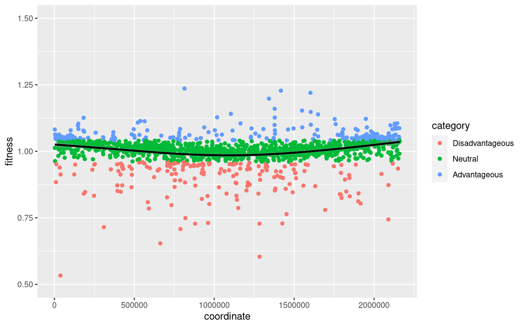

```r
df_plot <- data.frame(coordinate=fitness_gr$middle_coordinate,
                      fitness=fitness_gr$avg_fitness,
                      category=fitness_gr$gene_category)

ggplot(df_plot, aes(x=coordinate, y=fitness)) +
    geom_point(aes(color=category)) +
    geom_smooth(color='black') +
    ylim(0.5, 1.5)
```

As it’s clearly visible, genes at the extremities tend to have a higher fitness, while genes in the middle tend to have a lower fitness. Due to this, there are many genes in the extremities classified as advantageous and many genes in the middle classified as disadvantageous.

## Window statistics

Since in this model and in the following the genome is going to be divided into windows and for each one the middle coordinate and average fitness is computed, a function is defined and then reused:

```r
# Compute the middle coordinate of all genomic regions in a GRanges object
compute_middle_coord <- function(gr, gnome_length) {
  start <- min(start(gr))
  end <- max(end(gr))
  middle_coord <- round((end+start)/2)
  middle_coord_radians <- middle_coord*2*pi/genome_length
  return(c(middle_coord, middle_coord_radians))
}

# Compute the average of fitness of all genomic regions in a GRanges object
compute_avg_fitness <- function(gr) {
  avg_fitness <- mean(gr$avg_fitness)
  return(avg_fitness)
}

# This function takes as input the initial GRanges object and the window size
# It performs the following steps:
# 1. Define a GRanges object containing the windows in which the genome is divided
# 2. For each window, take the genes overlapping to that window and compute the
#    middle coordinate and the average of the fitness
# 3. Return a dataframe containing linear and radians coordinate and fitness
#    of each window
compute_window_statistics <- function(gr, window_size=100000) {
  # Define vector containing window start coordinates
  windows_start <- seq(from=min(start(gr)), to=max(end(gr)), by=window_size)

  # Build GRanges object containing the windows
  window_gr <- GRanges(seqnames=Rle("chr", length(windows_start)),
                       ranges=IRanges(start=windows_start, width=window_size))

  # Retrieve genome length (used to convert coordinates in radians)
  genome_length <- max(end(gr))

  # Build GRangesList object: at each loop of the lapply we consider one window
  # and we compute the statistics for the group of genes overlapping with the
  # window, returning a list containing them.

  window_statistics <- lapply(X=seq(1:length(window_gr)), FUN=function(X){
    # Select window
    window <- window_gr[X]

    # Subset by selected window
    window_overlapping_gr <- subsetByOverlaps(gr, window)

    # Compute window-related statistics
    window_coordinates <- compute_middle_coord(window, genome_length)
    window_avg_fitness <- compute_avg_fitness(window_overlapping_gr)
    return(c(window_coordinates, window_avg_fitness))
    }
  )

  # Convert the list of lapply into a dataframe
  df <- as.data.frame(do.call(rbind, window_statistics))
  colnames(df) <- c('coordinate','radians','fitness')
  return(df)
}
```

With this function the variables needed for the linear model are computed, using the default window size of 100000 nucleotides:

```r
window_statistics <- compute_window_statistics(fitness_gr)
window_statistics
```

| coordinate | radians | fitness |
| --- | --- | --- |
| 51716 | 0.1503782 | 1.0202464 |
| 151716 | 0.4411553 | 1.0247342 |
| 251716 | 0.7319323 | 1.0187164 |
| 351716 | 1.0227093 | 1.0005333 |
| 451716 | 1.3134863 | 0.9972576 |
| 551716 | 1.6042633 | 1.0085714 |
| 651716 | 1.8950403 | 1.0015294 |
| 751716 | 2.1858173 | 0.9857317 |
| 851716 | 2.4765943 | 0.9847536 |
| 951716 | 2.7673714 | 0.9837976 |

[output cut: 12 more lines]

# Linear Regression: linear coordinates

Since linear coordinates that are referred to a circular genome which is replicated in both directions are used, the linear model is trained on the first half of the genome and a modification of the first model is used for the second half.

```r
# Take genes overlapping with the first half of the genome and compute window statistics
first_half_gr <- subsetByOverlaps(fitness_gr, GRanges('chr', IRanges(0, genome_length/2)))
first_half_df_windows <- compute_window_statistics(first_half_gr, window_size=100000)

# Take genes overlapping with the second half of the genome and compute window statistics
second_half_gr <- subsetByOverlaps(fitness_gr, GRanges('chr', IRanges(genome_length/2, genome_length)))
second_half_df_windows <- compute_window_statistics(second_half_gr, window_size=100000)

# Fit model on the first half
lm_linear_coord <- lm(formula=fitness ~ coordinate, data=first_half_df_windows)
summary(lm_linear_coord)
```

```
Call:
lm(formula = fitness ~ coordinate, data = first_half_df_windows)

Residuals:
       Min         1Q     Median         3Q        Max
-0.0089495 -0.0068321 -0.0008419  0.0060953  0.0109298

Coefficients:
              Estimate Std. Error t value Pr(>|t|)
(Intercept)  1.023e+00  4.604e-03 222.217  < 2e-16 ***
coordinate  -3.868e-08  7.240e-09  -5.343 0.000466 ***
---
Signif. codes:  0 '***' 0.001 '**' 0.01 '*' 0.05 '.' 0.1 ' ' 1

Residual standard error: 0.007593 on 9 degrees of freedom
Multiple R-squared:  0.7603,    Adjusted R-squared:  0.7337
F-statistic: 28.55 on 1 and 9 DF,  p-value: 0.0004665
```

The R² and adjusted R² of this model is quite high and both the intercept and the coefficient for the coordinate variable are significant.

The fitness predicted by this model is now computed for the windows of the first half:

```r
# Predict first half (train)
first_half_pred_windows <- predict(lm_linear_coord, first_half_df_windows)
mean((first_half_pred_windows - first_half_df_windows$fitness)^2)
```

```
[1] 4.717526e-05
```

The MSE for the first half is quite low, indicating a good fit on the training data.

In order to predict the values for the second half, which have a distribution specular to the first half with respect to the middle of the genome, the first model is modified appropriately:

```r
# Predict second half (test)
## Get model coefficients
a <- coef(lm_linear_coord)['(Intercept)']
b <- coef(lm_linear_coord)['coordinate']

## The new model will be fitness ~ a - b*(coordinate - genome_length)
second_half_pred_windows <- a - b*(second_half_df_windows$coordinate - genome_length)
mean((second_half_pred_windows - second_half_df_windows$fitness)^2)
```

```
[1] 6.940841e-05
```

The MSE for the second half is quite similar to the one of the first, indicating that the model fits similarly on both and is suitable to model both the train and test data.

This model can now be used to correct the fitness values. In order to remove the dependency of fitness over the coordinate, the difference between the observed and the predicted fitness is computed.

Since in this way the data would be distributed around 0, and it is assumed that the fitness should be distributed around 1, the data is shifted by summing 1 to the difference obtained before.

```r
# Correct fitness values based on linear model
first_half_df_windows$corrected_fitness <- first_half_df_windows$fitness - first_half_pred_windows + 1
second_half_df_windows$corrected_fitness <- second_half_df_windows$fitness - second_half_pred_windows + 1

# Concatenate the two halves
window_statistics_linear <- rbind(first_half_df_windows, second_half_df_windows)
```

In order to visualize the effect of this correction, a function to plot the data before and after correction is defined and used:

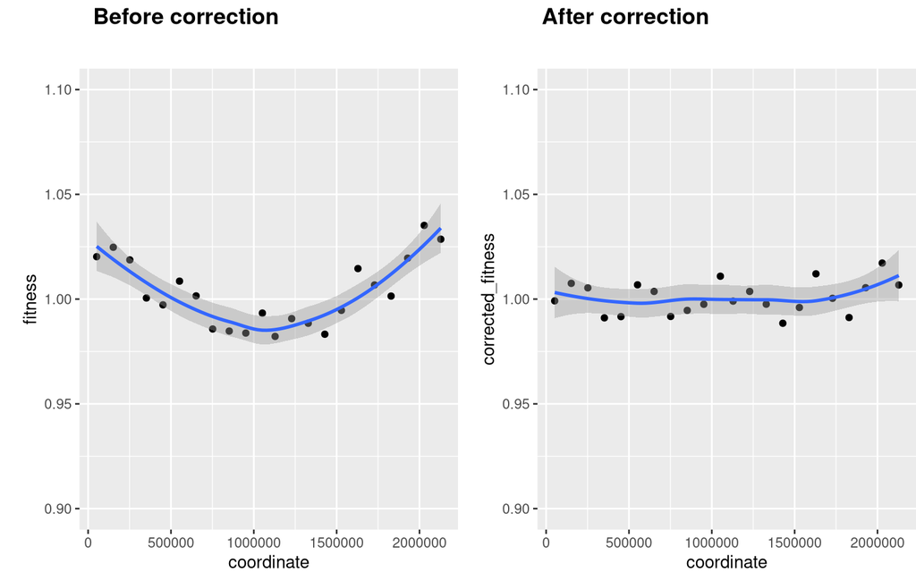

```r
correction_plots_windows <- function(df, x) {

  plot1 <- ggplot(df, aes(x=.data[[x]], y=fitness)) +
    geom_point() +
    geom_smooth() +
    ylim(0.9, 1.1) +
    theme(plot.margin=unit(c(3,0,0,1), "lines"))

  plot2 <- ggplot(df, aes(x=.data[[x]], y=corrected_fitness)) +
    geom_point() +
    geom_smooth() +
    ylim(0.9, 1.1) +
    theme(plot.margin=unit(c(3,0,0,1), "lines"))

  plot_grid(plot1, plot2, ncol=2, label_x=0,
            labels=c('Before correction', 'After correction'))
}

correction_plots_windows(window_statistics_linear, x='coordinate')
```

The correction seems to perform well on the windows, since in the second plot the line is quite straight around 1. Having visual proof that this model works for fitness correction, it can now be used on the data of all the genes in the same way:

```r
# Predict fitness for genes in the first half
first_half_df_all <- data.frame(coordinate=first_half_gr$middle_coordinate,
                                fitness=first_half_gr$avg_fitness)

first_half_pred_all <- predict(lm_linear_coord, first_half_df_all)
first_half_df_all$corrected_fitness <- first_half_df_all$fitness - first_half_pred_all + 1


# Predict fitness for genes in the second half
second_half_df_all <- data.frame(coordinate=second_half_gr$middle_coordinate,
                                 fitness=second_half_gr$avg_fitness)

second_half_pred_all <- a - b*(second_half_df_all$coordinate - genome_length)
second_half_df_all$corrected_fitness <- second_half_df_all$fitness - second_half_pred_all + 1

# Concatenate the two halves
all_df_linear <- rbind(first_half_df_all, second_half_df_all)

# Remove possible duplicates (genes possibly overlapping both halves of the genome)
all_df_linear <- all_df_linear[!duplicated(all_df_linear$coordinate),]
```

With the new fitness, a corrected catogery can be assigned to each gene, which may be different from the one assigned with the previous fitness:

```r
# Add previous category to dataframe
all_df_linear$category_before <- fitness_gr$gene_category

# Add new category
all_df_linear$category_after <- cut(all_df_linear$corrected_fitness,
                                    breaks=fitness_breakpoints,
                                    labels=fitness_categories)
```

To better visualize the effect of fitness correction on each gene, a function similar to the one used before, which also shows the gene cateogry, is used:

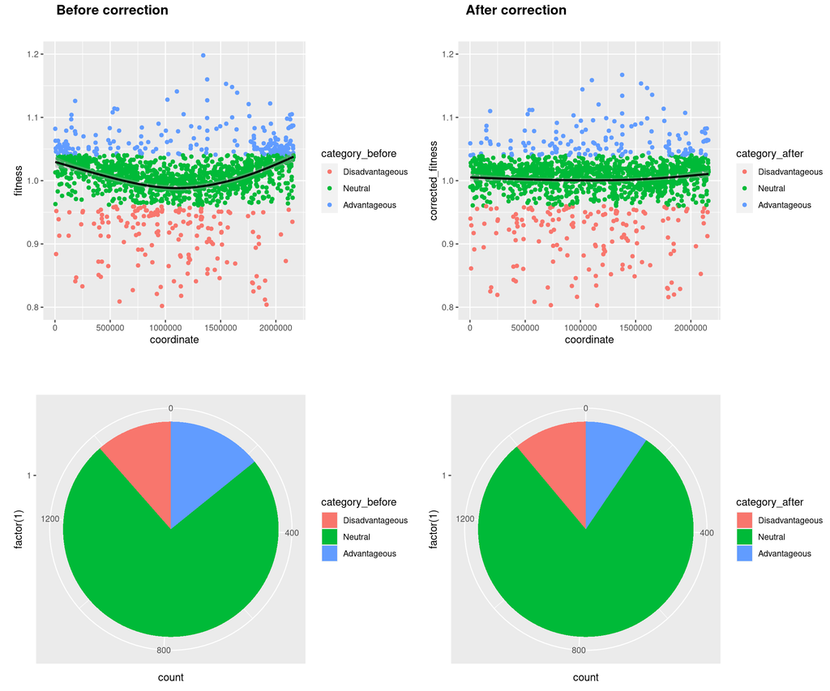

```r
correction_plots <- function(df, x) {
  # First scatterplot, before correction
  plot1 <- ggplot(df, aes(x=.data[[x]], y=fitness)) +
    geom_point(aes(color=category_before)) +
    geom_smooth(color='black') +
    ylim(0.8, 1.2) +
    theme(plot.margin = unit(c(3,0,0,1), "lines"))

  # Second scatterplot, after correction
  plot2 <- ggplot(df, aes(x=.data[[x]], y=corrected_fitness)) +
    geom_point(aes(color=category_after)) +
    geom_smooth(color='black') +
    ylim(0.8, 1.2) +
    theme(plot.margin = unit(c(3,0,0,1), "lines"))

  # First barplot, before correction
  plot3 <- ggplot(df, aes(x=factor(1), fill=category_before)) +
    geom_bar(stat="count") +
    coord_polar("y") +
    theme(plot.margin = unit(c(3,0,0,1), "lines"))

  # Second barplot, after correction
  plot4 <- ggplot(df, aes(x=factor(1), fill=category_after)) +
    geom_bar(stat="count") +
    coord_polar("y") +
    theme(plot.margin = unit(c(3,0,0,1), "lines"))

  # Show plots
  plot_grid(plot1, plot2, plot3, plot4, ncol=2, nrow=2,
            labels=c('Before correction', 'After correction'), label_x=0)
}

correction_plots(all_df_linear,x='coordinate')
```

After fitness correction, the data is distributed around 1 and the ‘smile effect’ disappear, even though there seems to be a flex near the end of the genome. As for the gene category, a lower number of disadvantageous and advantageous genes is observed after correction, with a higher number of neutral genes. These are most probably mainly genes misclassified due to their position being in the extremities and in the middle of the genome.

# Linear Regression: radians coordinates

Even though the first model performed well, it may be useful to consider the coordinates of each gene in a polar coordinate system. In that way, the fact that the genome is circular is taken into account directly in the data and it won’t be necessary to split the data in two.

Also in this case, the model is fitted on window-averged data, using windows of 100000 nucleotides. Since the dataframe containing the radians coordinates and the fitness of each window as already been built, it will be used as a starting point.

When dealing with circular variables and a periodic structure of the data, the sine and cosine functions are usually exploited (mainly in pairs) to better model the fact that the beginning of the scale is the same as the end, i.e. position 0 of the linear genome is equal to the position at the end of the genome (source: Stata Journal, https://www.stata-journal.com/sjpdf.html?articlenum=st0116).

```r
# Use dataframe to build model with radians
window_statistics_radians <- window_statistics

# Fit model
lm_radians <- lm(formula=fitness ~ sin(radians) + cos(radians), data=window_statistics_radians)
summary(lm_radians)
```

```
Call:
lm(formula = fitness ~ sin(radians) + cos(radians), data = window_statistics_radians)

Residuals:
       Min         1Q     Median         3Q        Max
-0.0124321 -0.0069136  0.0007805  0.0066234  0.0103305

Coefficients:
              Estimate Std. Error t value Pr(>|t|)
(Intercept)   1.003120   0.001669 601.205  < 2e-16 ***
sin(radians) -0.001310   0.002380  -0.550    0.588
cos(radians)  0.021041   0.002339   8.996 2.81e-08 ***
---
Signif. codes:  0 '***' 0.001 '**' 0.01 '*' 0.05 '.' 0.1 ' ' 1

Residual standard error: 0.007824 on 19 degrees of freedom
Multiple R-squared:  0.8104,    Adjusted R-squared:  0.7905
F-statistic: 40.61 on 2 and 19 DF,  p-value: 1.378e-07
```

The R² and the adjusted R² of this model is better than the first one. Even though the coefficient of the sine term is not significant, the R² of this model is slightly better than the one without it (not shown here).

The fitness of each window can be now corrected with this model to see if the correction works as expected in the same way as before:

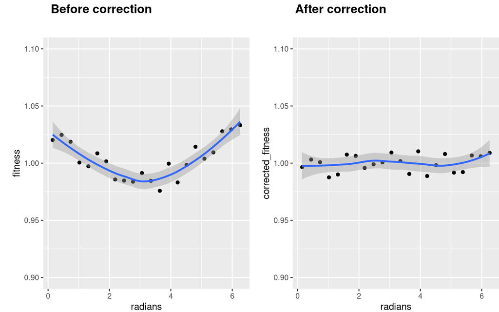

```r
# Predict window fitness with the radians model
predicted_fitness <- predict(lm_radians, window_statistics_radians)

# Correct window fitness
window_statistics_radians$corrected_fitness <- window_statistics_radians$fitness - predicted_fitness + 1

# Plot window fitness correction
correction_plots_windows(window_statistics_radians, x='radians')
```

The model seems to perform similarly with respect to the first one, and it can now be used to correct the fitness values of each gene:

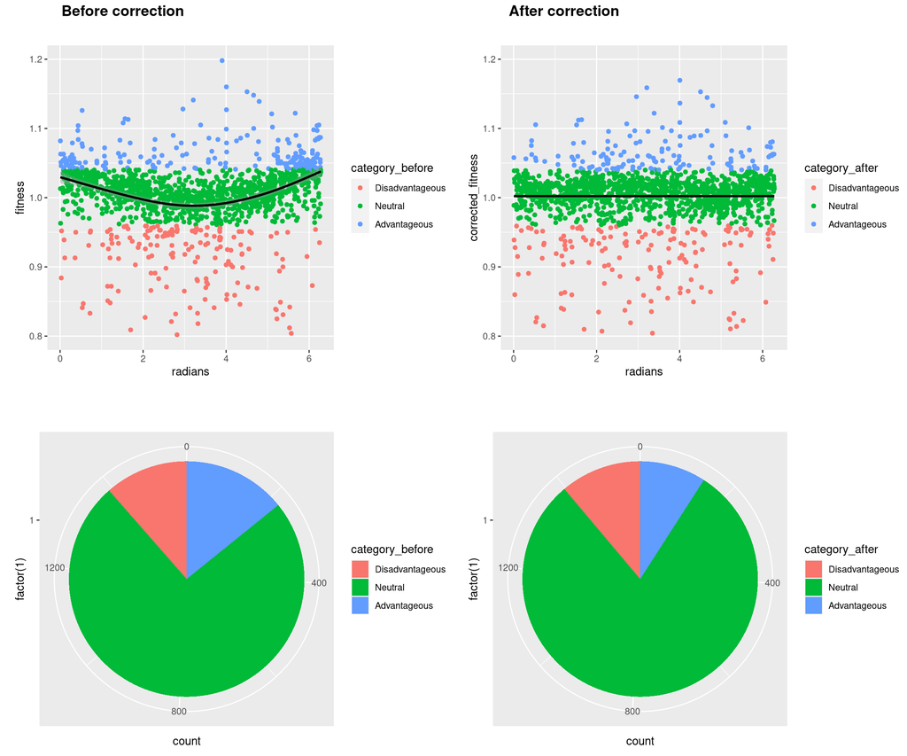

```r
# Build dataframe to use with the linear model
all_df_radians <- data.frame(radians=fitness_gr$radians_coordinate,
                             fitness=fitness_gr$avg_fitness,
                             category_before=factor(fitness_gr$gene_category))

# Compute corrected fitness values
all_df_radians$corrected_fitness <- all_df_radians$fitness - predict(lm_radians, all_df_radians) + 1

# Add new gene category based on corrected fitness
all_df_radians$category_after <- cut(all_df_radians$corrected_fitness,
                                     breaks=fitness_breakpoints,
                                     labels=fitness_categories)

# Plot fitness correction
correction_plots(all_df_radians,x='radians')
```

Considering the results on all the genes, this model seems to perform better at fitness correction, since it transform the data into an almost completely straight distribution around 1 also in the genome extremities.

For this reason, this model will be used from now on.

A similar rate of change of category after fitness correction is observed with respect to the previous model.

# Gene category change

## Visualization of circular coordinates

To better visualize the difference in fitness interpretation with and without the correction based on position, a circular plot may be useful. In this way, a further confirmation can be obtained that the bias introduced in sites proximal to the origin of replication is present and is removed by the correction.

For this purpose smaller windows of the genome are used, so that the change in gene category can be observed in more detail. A window of 5000 nucleotides is used:

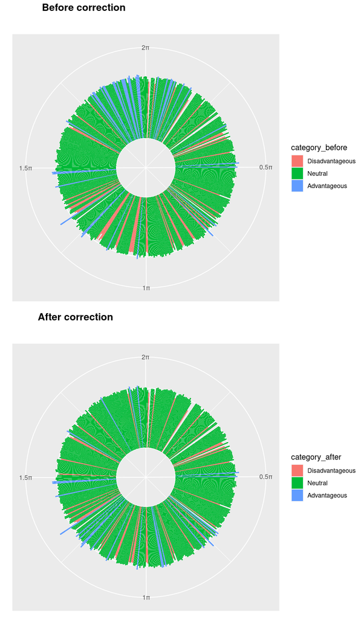

```r
# Build dataframe with windows of 5000 nt for circular plot
window_plot_df <- compute_window_statistics(fitness_gr, 5000)
window_plot_df$category_before <- cut(window_plot_df$fitness,
                                      breaks=fitness_breakpoints,
                                      labels=fitness_categories)

# Correct fitness with radians model
window_plot_df$corrected_fitness <- window_plot_df$fitness - predict(lm_radians, window_plot_df) + 1
window_plot_df$category_after <- cut(window_plot_df$corrected_fitness,
                                     breaks=fitness_breakpoints,
                                     labels=fitness_categories)


# Build scale with pi for plot axis
pi_scales <- math_format(.x*pi, format = function(x) x / pi)

# Plot before correction
plot1 <- ggplot(window_plot_df) +
  geom_bar(aes(x=radians, y=fitness, fill=category_before), stat="identity") +
  ylim(-0.5,1.3) +
  theme(axis.title = element_blank(),
        axis.ticks.y = element_blank(),
        axis.text.y = element_blank()) +
  coord_polar(start=0) +
  scale_x_continuous(labels=pi_scales, breaks=seq(0, 2*pi, pi/2)) +
  theme(plot.margin = unit(c(3,0,0,1), "lines"))


# Plot after correction
plot2 <- ggplot(window_plot_df) +
  geom_bar(aes(x=radians, y=corrected_fitness, fill=category_after), stat="identity") +
  ylim(-0.5,1.3) +
  theme(axis.title = element_blank(),
        axis.ticks.y = element_blank(),
        axis.text.y = element_blank()) +
  coord_polar(start=0) +
  scale_x_continuous(labels=pi_scales, breaks=seq(0, 2*pi, pi/2)) +
  theme(plot.margin = unit(c(3,0,0,1), "lines"))

# Show plots together
plot_grid(plot1, plot2, nrow=2, label_x=0,
          labels=c('Before correction', 'After correction'))
```

From the first circular plot it can be seen that before correction, many genes near the origin of replication (upper portion, around 2π) have a fitness significantly higher than 1, causing more windows to be classified as advantageous. The opposite is true for the genes furthest from the origin of replication (lower portion, around π), which cause more windows to be classified as disadvantageous.

By applying fitness correction, the distribution of advantageous and disadvantageous genes mutations seems to be spread more evenly around the genome.

## Visualization of category change

To better visualize the shift of category before and after fitness correction, a Sankey plot may be useful. To plot it, the dataframe used to fit the linear model with radians needs to be transformed:

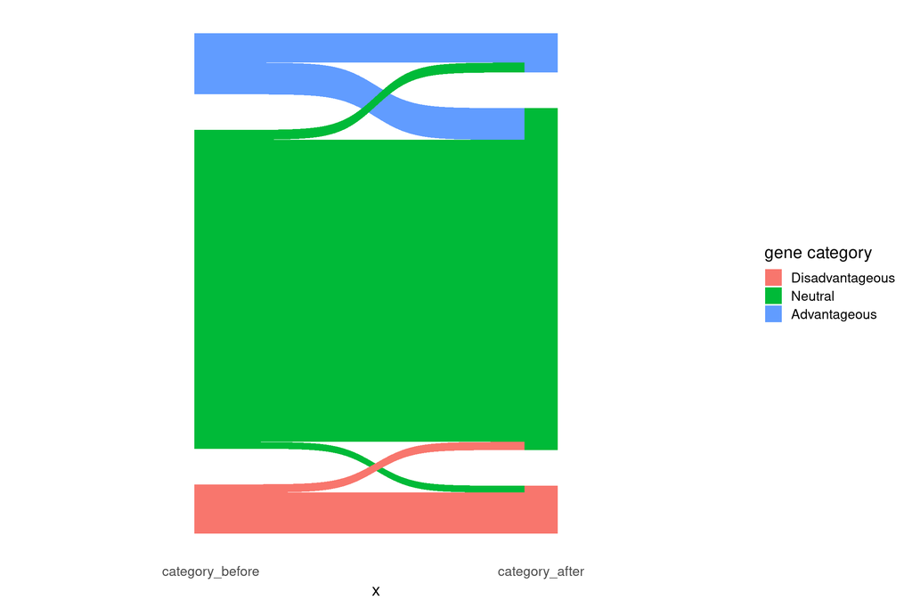

```r
df_sankey_plot <- all_df_radians %>% ggsankey::make_long(category_before, category_after)

ggplot(df_sankey_plot, aes(x=x, next_x=next_x,
                           node=factor(node, levels=fitness_categories),
                           next_node=factor(next_node, levels=fitness_categories),
                           fill=factor(node, levels=fitness_categories))) +
  geom_sankey() +
  guides(fill=guide_legend(title="gene category")) +
  theme_sankey(base_size=16)
```

As can be seen from the Sankey plot, most of the category change is due to genes originally misclassified as advantageous, which are in reality neutral.

## Gene Ontology Terms

It may be interesting to see which are the genes misclassified as neutral, that actually have a positive or negative effect on fitness when disrupted. Starting from this gene set, it may be possible to perform Gene Set Enrichment Analysis (GSEA) in order to test a possible enrichment of a biological function which is common to them that may confirm their influence on fitness.

In this project, qualitative analysis on the biological function of the genes initially misclassified as neutral is performed. By taking the symbols of these genes, the UniProt API is used to retrieve the Gene Ontology Terms associated with them in order to get an overview of their function.

First, two gene lists are saved in two files:

- Genes initially misclassified as neutral that actually have an advantageous insertion.
- Genes initially misclassified as neutral that acctualy have a disadvantageous insertion.

```r
# Add gene symbol
all_df_radians$symbol <- names(fitness_gr)

# Get gene lists
neutral_to_advantageous <- all_df_radians[all_df_radians$category_before=='Neutral' &
                                          all_df_radians$category_after=='Advantageous',]$symbol

neutral_to_disadvantageous <- all_df_radians[all_df_radians$category_before=='Neutral' &                                                                         all_df_radians$category_after=='Disadvantageous',]$symbol

# Save gene lists to files
write.table(neutral_to_advantageous, './neutral_to_advantageous.csv',
            row.names=FALSE, col.names=FALSE, quote=FALSE)
write.table(neutral_to_disadvantageous, './neutral_to_disadvantageous.csv',
            row.names=FALSE, col.names=FALSE, quote=FALSE)
```

The following code is written in bash because of the better management of the API output with the CLI tool jq. With the two while loops, the genes in the two gene sets are searched with the UniProt API and the GoTerms associated with them are retrieved. With the query field in the API url the taxonomy ID for S. pneumoniae TIGR4 (170187) is passed together with the gene name:

```bash
# Retrieve GoTerms for neutral to advantageous genes
while IFS= read -r gene;
do
  curl -s https://rest.uniprot.org/uniprotkb/search?query=%28taxonomy_id%3A170187%29%20${gene} | jq '.results[].uniProtKBCrossReferences[] | select(.database=="GO") | .properties[] |   select(.key=="GoTerm") | .value';
done < ./neutral_to_advantageous.csv > ./neutral_to_advantageous_goterms.txt;

# Retrieve GoTerms for neutral to advantageous genes
while IFS= read -r gene;
do
  curl -s https://rest.uniprot.org/uniprotkb/search?query=%28taxonomy_id%3A170187%29%20${gene} | jq '.results[].uniProtKBCrossReferences[] | select(.database=="GO") | .properties[] | select(.key=="GoTerm") | .value';
done < ./neutral_to_disadvantageous.csv > ./neutral_to_disadvantageous_goterms.txt;
```

By having a look at the two files generated (neutral_to_advantageous_goterms.txt and neutral_todisadvantageous_goterms.txt) it’s possible to evaluate if it is reasonable that these genes actually have an impact on the cell fitness.

Genes whose mutation has been misclassified as neutral and is instead advantageous show some GO terms that may explain their effect on cell fitness. Some terms indicate that this gene set is composed of some genes that are related to the cell response to stress:

- protein repair;
- response to oxidative stress;
- nucleotide-excision repair;
- SOS response.

An hypothesis could be that he removal of these genes may prevent the bacterium from inducing stress reponse and apoptosis in stress conditions, increasing fitness.

There are also GO terms that may be of interest in the set of genes whose mutation has been misclassified as neutral and is instead disadvantageous. Those terms indicate that this gene set is composed of some genes that are related to the basic functions needed for the cell life, like DNA and protein synthesis and metabolic processes:

- DNA synthesis related terms:
  - DNA replication
  - ribonucleoside-triphosphate reductase activity
- protein synthesis related terms:
  - mature ribosome assembly
  - protein folding
  - peptide transport
  - protein transport
  - threonine synthase activity
- metabolic process related terms:
  - carbohydrate derivative biosynthetic process
  - carbohydrate metabolic process
  - thiamine diphosphate biosynthetic process

A mutation of genes that have this kind of function may influence negatively the cell survival, since it may interfere with the cell metabolism.

Of course, these observations are limited by the fact that they are purely qualitative. A GSEA or GO enrichment analysis would be more appropriate. An attempt was done to perform the two on http://www.webgestalt.org/ and http://geneontology.org/ respectively, but without success due to the fact that S. pneumoniae TIGR4 data and annotations could not be found, possibly because newer annotations for S. pneumoniae are now used.

# Conclusions

A model using circular genomic coordinates in radians was successfully fitted on Tn-seq data in order to correct the bias in the fitness distribution.

A fitness evenly distributed around 1 was obtained by applying the model and removing the fitness dependency on the genome coordinate. This allowed to find some genes which were misclassified with the original fitness.

By looking at Gene Ontology terms associated with the genes wrongly classified as neutral, it was possible to verify that those genes actually may have a role in the cell success in survival and reproduction, explaining why their mutation may actually influence cell fitness.